# Plotting Ocean Data With R: Challenge Solutions

Here are the solutions to the Challenges in the main tutorial `Plotting Ocean Data With R`

## Initialize session

We first need to load the `tidyverse` library:

```r
library(tidyverse)
```

and the data:

```r
fieldData <- read_csv('DamariscottaRiverData.csv')
```

## Challenge A

1.a. Create a scatter plot of ‘temperature_degC’ by ‘fluorescence_mg_m3’ and color the points by ‘station’.

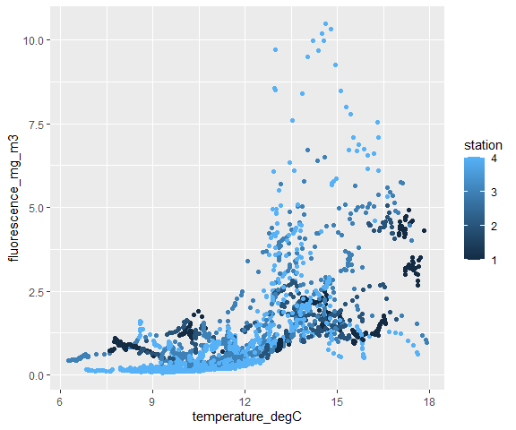

```r
ggplot(data = fieldData, mapping = aes(x = temperature_degC, y = fluorescence_mg_m3)) +
  geom_point(aes(color=station))
```

1.b. Do the same as 1.a. but convert the station values to factors. What’s the difference between the two plots?

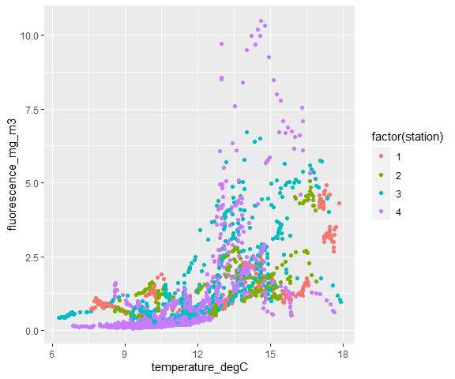

```r
ggplot(data = fieldData, mapping = aes(x = temperature_degC, y = fluorescence_mg_m3)) +
  geom_point(aes(color=factor(station)))
```

In the first plot, the colors are on a continuous colorscale. In the second plot, the colors are discrete, separate colors. When the data was read into R, the station values were read in as numeric values, so R plotted them on a continuous color scale. But the station number can really be though of as discrete data - they didn’t *need* to be numbers, they could have been letters, or names. The station numbers are separate from each other - not part of a continuous scale. So, to plot them as four separate entities, we need to tell R to treat the station column as factors (as it would have automatically done if the stations were named “A”, “B”, “C”, and “D”).

2. Create boxplots looking at the distribution of temperature_degC by station (tip: change the station values to factors)

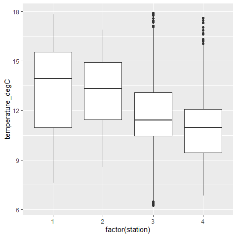

```r
ggplot(data = fieldData, mapping = aes(x = factor(station), y = temperature_degC)) +
  geom_boxplot()
```

3. Plot temperature by depth for samples from 2016, coloring the points by station

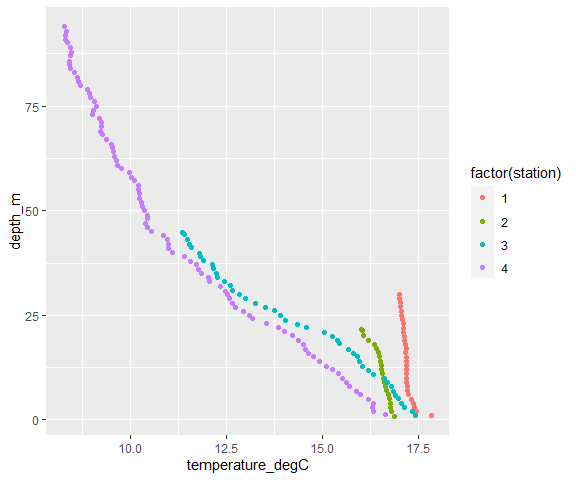

```r
datasubset <- fieldData %>% filter(date==20160908)

ggplot(data = datasubset, mapping = aes(x = temperature_degC, y = depth_m)) +
  geom_point(aes(color=factor(station)))
```

## Challenge B

What are the steps we need to take to manipulate our data into a data frame with three columns: cruise, station and fluorescence averaged over the top 2 m? Describe the step and say the associated `dplyr` data frame manipulation functions you would use to do it.

1. Select the rows where the depth is 2 m or less (use `filter`)
2. Separate the data into date and station groups (use `group_by`)
3. Take the average for each group of data (use `summarize`)

Use the pipes to connect all three steps together.

## Challenge C

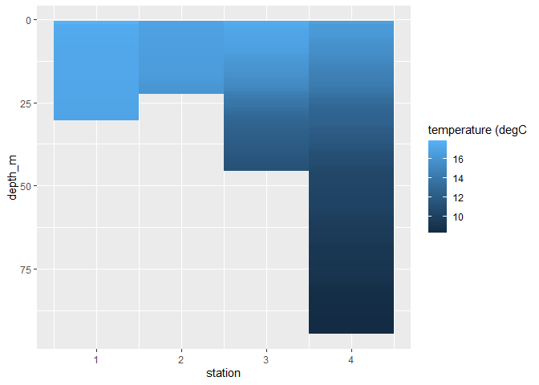

```r
cruiseData <- filter(fieldData, date==20160908)
ggplot(cruiseData,aes(x=station,y=depth_m)) +
  geom_tile(aes(fill=temperature_degC)) +
  #scale_fill_continuous() +
  labs(fill='temperature (degC') +
  scale_y_reverse()
```

2. Are there any examples from your own data that you could plot in this way?

[Here’s an example with genomic data](https://science.sciencemag.org/content/sci/358/6366/1046/F2.large.jpg) that was created using `geom_tile`.